# Data Science Capstone Project - Milestone Report

Hasan Shojaei

12/10/2018

## Executive Summary

The main goal of this project is to create a Shiny app in which the user enters a few words and the app predicts and suggests the 3 most likely word to follow. The prediction algorithm will be based on an n-gram model, and will be trained using the SwiftKey Dataset.

In this milestone report we present our exploratory data analysis of the SwiftKey dataset. This includes tables and plots summarizing the numnber of words and lines in each of the 3 English files (blogs, news, twitter). We also explore the frequencies of words, bigrams and trigrams found in a sample taken form the files (5% of the lines). At the end of the report we will include a section describing our goals for the eventual algorithm and app.

## Loading Required R Packages

```r
# load required R packages
library(tm)
library(dplyr)
library(ggplot2)
library(gridExtra)
library(knitr)
```

## Files Summary

```r
# set options
options(stringsAsFactors = FALSE)

# get list of files
flist <- list.files()

# define a function to extract important info about each file
file_stat <- function(f) {
  fsize <- file.info(f)[1]/1024/1024
  lines <- readLines(f, skipNul = TRUE)
  nwords <- sum(sapply(strsplit(lines, "\\s+"), length))
  return(c(f, round(fsize, 2), length(lines), nwords))
}

# apply the function to all the files
stats_list <- lapply(flist, file_stat)

# put the results in a data frame
df <- data.frame(matrix(unlist(stats_list), nrow=length(stats_list), byrow=T))
colnames(df) <- c("File", "Size(MB)", "Num_of_Lines", "Num_of_Words")

# show the summary in a neat table
kable(df, format = "markdown")
```

| File | Size(MB) | Num_of_Lines | Num_of_Words |
| --- | --- | --- | --- |
| en_US.blogs.txt | 200.42 | 899288 | 37334149 |
| en_US.news.txt | 196.28 | 1010242 | 34372814 |
| en_US.twitter.txt | 159.36 | 2360148 | 30373605 |

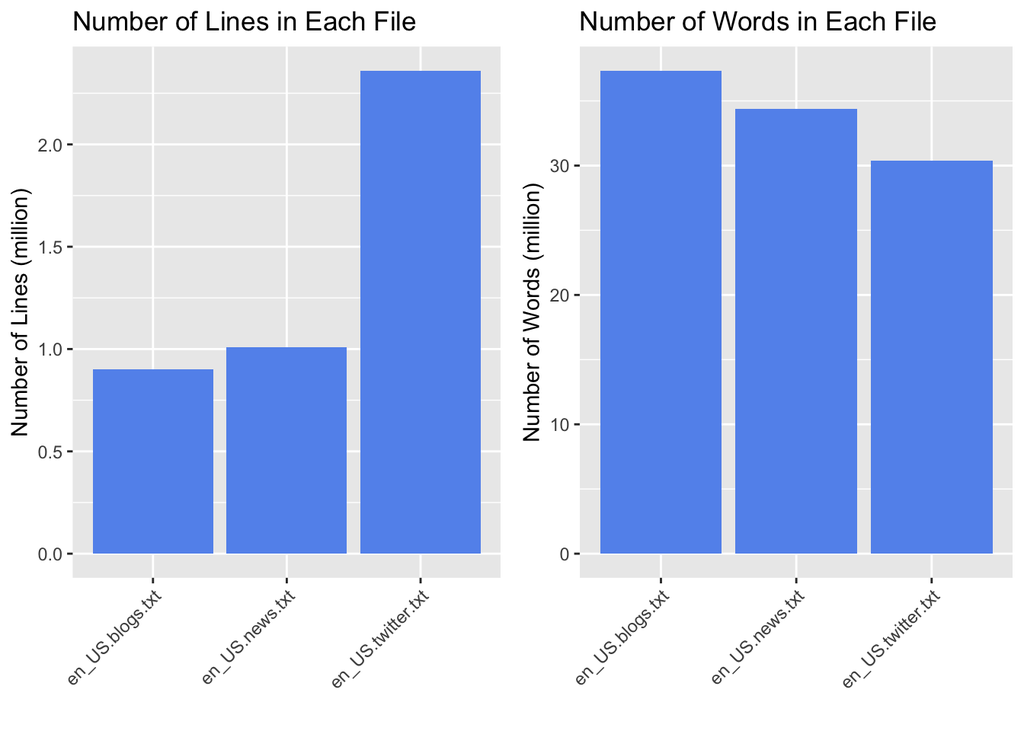

```r
# present the summary as bar charts
df$Num_of_Lines <- as.numeric(df$Num_of_Lines)
df$Num_of_Words <- as.numeric(df$Num_of_Words)

g1 <- ggplot(df, aes(x = factor(File), y = Num_of_Lines/1e+06)) +
  geom_bar(stat = "identity", fill="cornflowerblue") +
  labs(y = "Number of Lines (million)", x = "", title = "Number of Lines in Each File") +
  theme(axis.text.x=element_text(angle=45, hjust=1))

g2 <- ggplot(df, aes(x = factor(File), y = Num_of_Words/1e+06)) +
  geom_bar(stat = "identity", fill="cornflowerblue") +
  labs(y = "Number of Words (million)", x = "", title = "Number of Words in Each File") +
  theme(axis.text.x=element_text(angle=45, hjust=1))

grid.arrange(g1, g2, ncol=2)
```

## Sampling from the Data

To get a sense of the data, we take a small sample from each of the 3 files (5% of the lines) and perform exploratory data analysis on the sample.

```r
# define a function to sample from each files
file_sample <- function(f) {
  lines <- readLines(f, skipNul = TRUE)
  smpl <- sample(lines, round(0.05*length(lines)), replace = FALSE)
  return(c(f,smpl))
}

# apply the function to all the files
samples_list <- lapply(flist, file_sample)

# create a "Volatile Corpus" by putting together samples from all 3 files
docs <- VCorpus(VectorSource(samples_list))

# assign ID to each part of the corpus
for (i in 1:length(docs)) {
   attr(docs[[i]], "ID") <- samples_list[[i]][1]
}
```

## Pre-Procesing

```r
# define necessary functions for pre-processing
removeForeign <- function(x) iconv(x,"latin1","ASCII",sub = "")
removeURL <- function(x) gsub("http:[[:alnum:]]*", "", x)
removeHashtag <- function(x) gsub("#\\S+", "", x)
removeUsername <- function(x) gsub("@\\S+", "", x)

PreProcess <- function(doc){
  #doc <- tm_map(doc, removeWords, cursewords)
  doc <- tm_map(doc, removeWords, stopwords("english"))
  doc <- tm_map(doc, removePunctuation)
  doc <- tm_map(doc, removeNumbers)
  doc <- tm_map(doc, stripWhitespace)
  doc <- tm_map(doc, content_transformer(tolower))
  doc <- tm_map(doc, content_transformer(removeForeign))
  doc <- tm_map(doc, content_transformer(removeURL))
  doc <- tm_map(doc, content_transformer(removeHashtag))
  doc <- tm_map(doc, content_transformer(removeUsername))
  #doc <- tm_map(doc, PlainTextDocument)
  return(doc)
}

# apply the pre-processing function on the corpus
docs <- PreProcess(docs)
```

## Tokenization

In this section we tokenize the text. In other words we extract unigrams (words), bigrams (groups of two consecutive words) and trigrams (groups of three consecutive words). These n-grams will be used later to build and train a prediction algorithm for our Shiny app.

```r
 # define required functions for tokenization
BigramTokenizer <- function(x) unlist(lapply(ngrams(words(x), 2), paste, collapse = " "), use.names = FALSE)
TrigramTokenizer <- function(x) unlist(lapply(ngrams(words(x), 3), paste, collapse = " "), use.names = FALSE)

# tokenize the text
Unigram_tdm <- TermDocumentMatrix(docs)
Bigram_tdm <- TermDocumentMatrix(docs, control = list(tokenize = BigramTokenizer))
Trigram_tdm <- TermDocumentMatrix(docs, control = list(tokenize = TrigramTokenizer))
```

## N-gram Frequencies

In this section we calculate the frequencies of different n-grams, and generate histograms by plotting 20 most frequent n-grams.

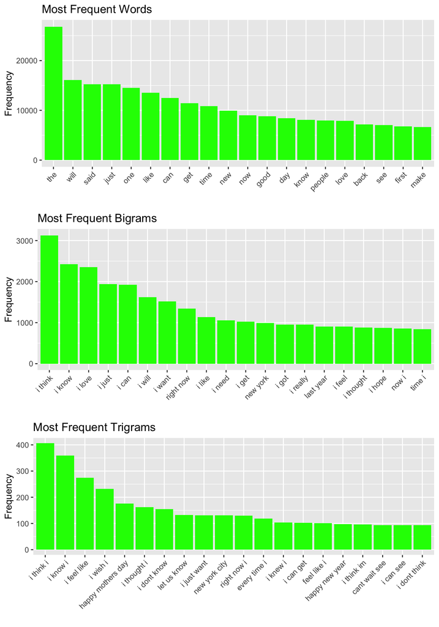

```r
# number of most frequent n-grams to show
n <- 20

# find most frequent n-grams
UnigramFreq <- findFreqTerms(Unigram_tdm, n)
BigramFreq <- findFreqTerms(Bigram_tdm, n)
TrigramFreq <- findFreqTerms(Trigram_tdm, n)

# generate sorted data frames
UnigramFrequencies <- rowSums(as.matrix(Unigram_tdm[UnigramFreq,]))
UnigramFrequencies <- data.frame(Word=names(UnigramFrequencies),Frequency=UnigramFrequencies)
UnigramFrequencies <- UnigramFrequencies[order(-UnigramFrequencies$Frequency),]

BigramFrequencies <- rowSums(as.matrix(Bigram_tdm[BigramFreq,]))
BigramFrequencies <- data.frame(Word=names(BigramFrequencies),Frequency=BigramFrequencies)
BigramFrequencies <- BigramFrequencies[order(-BigramFrequencies$Frequency),]

TrigramFrequencies <- rowSums(as.matrix(Trigram_tdm[TrigramFreq,]))
TrigramFrequencies <- data.frame(Word=names(TrigramFrequencies),Frequency=TrigramFrequencies)
TrigramFrequencies <- TrigramFrequencies[order(-TrigramFrequencies$Frequency),]

# plot the results
UnigramFrequencies$Word <- as.character(UnigramFrequencies$Word)
UnigramFrequencies$Word <- factor(UnigramFrequencies$Word, levels = UnigramFrequencies$Word)
g3 <- ggplot(UnigramFrequencies[1:n,], aes(x = Word, y = Frequency)) +
  geom_bar(stat = "identity", fill="green") +
  labs(title = "Most Frequent Words", x="")+
  theme(axis.text.x=element_text(angle=45, hjust=1))

BigramFrequencies$Word <- as.character(BigramFrequencies$Word)
BigramFrequencies$Word <- factor(BigramFrequencies$Word, levels = BigramFrequencies$Word)
g4 <- ggplot(BigramFrequencies[1:n,], aes(x = Word, y = Frequency)) +
  geom_bar(stat = "identity", fill="green") +
  labs(title = "Most Frequent Bigrams", x="")+
  theme(axis.text.x=element_text(angle=45, hjust=1))

TrigramFrequencies$Word <- as.character(TrigramFrequencies$Word)
TrigramFrequencies$Word <- factor(TrigramFrequencies$Word, levels = TrigramFrequencies$Word)
g5 <- ggplot(TrigramFrequencies[1:n,], aes(x = Word, y = Frequency)) +
  geom_bar(stat = "identity", fill="green") +
  labs(title = "Most Frequent Trigrams", x="")+
  theme(axis.text.x=element_text(angle=45, hjust=1))

grid.arrange(g3, g4, g5, ncol=1)
```

## Next Steps

In the remainder of this project we will build an n-gram model for predicting the next word based on the previous 1, 2, or 3 words. We aim to build a model that handles unseen n-grams becuase a user may enter a combination of words that has not been observed in the corpora before. This will be achieved by smoothing the probabilities (i.e. giving all n-grams a non-zero probability even if they have not been observed in the data). We will also pay special attention to the efficiency of our algorithm which is determined by the size (physical RAM required) and runtime (the amount of time the algorithm takes to make a prediction) of the algorithm. This is very important because our prediction algorithm will need to run in a Shiny app.